# Answers for in-class exercise - Lesson 9: Relational data

## Practicing `join` functions

#### This exercise is borrowed from the [STAT545 course at UBC](https://stat545guidebook.netlify.app/tibble-joins.html)

For this exercise, we will need two data files from Joey Bernhardt’s R package `singer`. We have to first load the `tidyverse` library, then we can load these datasets from the STAT545 GitHub repo with the following lines of code:

## Exercise 1: `singer`

The package `singer` comes with two smallish data frames about songs. Let’s first import them and take a look at them (after minor modifications by renaming and shuffling):

Import the data

```r
library(tidyverse)

songs <- read_csv("https://raw.githubusercontent.com/STAT545-UBC/Classroom/master/data/singer/songs.csv")
locations <- read_csv("https://raw.githubusercontent.com/STAT545-UBC/Classroom/master/data/singer/loc.csv")
```

```r
(time <- as_tibble(songs) %>%
   rename(song = title))
```

```
## # A tibble: 22 x 3
##    song                             artist_name      year
##    <chr>                            <chr>           <dbl>
##  1 Corduroy                         Pearl Jam        1994
##  2 Grievance                        Pearl Jam        2000
##  3 Stupidmop                        Pearl Jam        1994
##  4 Present Tense                    Pearl Jam        1996
##  5 MFC                              Pearl Jam        1998
##  6 Lukin                            Pearl Jam        1996
##  7 It's Lulu                        The Boo Radleys  1995
##  8 Sparrow                          The Boo Radleys  1992
##  9 Martin_ Doom! It's Seven O'Clock The Boo Radleys  1995
## 10 Leaves And Sand                  The Boo Radleys  1993
## # … with 12 more rows
```

```r
(album <- as_tibble(locations) %>%
   select(title, everything()) %>%
   rename(album = release,
          song  = title))
```

```
## # A tibble: 14 x 4
##    song                          artist_name    city        album
##    <chr>                         <chr>          <chr>       <chr>
##  1 "Grievance"                   Pearl Jam      Seattle, WA Binaural
##  2 "Stupidmop"                   Pearl Jam      Seattle, WA Vitalogy
##  3 "Present Tense"               Pearl Jam      Seattle, WA No Code
##  4 "MFC"                         Pearl Jam      Seattle, WA Live On Two Legs
##  5 "Lukin"                       Pearl Jam      Seattle, WA Seattle Washington …
##  6 "Stuck On Amber"              The Boo Radle… Liverpool,… Wake Up!
##  7 "It's Lulu"                   The Boo Radle… Liverpool,… Best Of
##  8 "Sparrow"                     The Boo Radle… Liverpool,… Everything's Alrigh…
##  9 "High as Monkeys"             The Boo Radle… Liverpool,… Kingsize
## 10 "Butterfly McQueen"           The Boo Radle… Liverpool,… Giant Steps
## 11 "My One and Only Love"        Carly Simon    New York, … Moonlight Serenade
## 12 "It Was So Easy  (LP Version… Carly Simon    New York, … No Secrets
## 13 "I've Got A Crush On You"     Carly Simon    New York, … Clouds In My Coffee…
## 14 "Manha De Carnaval (Theme fr… Carly Simon    New York, … Into White
```

1. We really care about the songs in `time`. But, which of those songs do we know its corresponding album?

```r
# Let's first remind ourselves of the variable names in each dataframe
colnames(time)
```

```
## [1] "song"        "artist_name" "year"
```

```r
colnames(album)
```

```
## [1] "song"        "artist_name" "city"        "album"
```

```r
# What we should notice about the two tibbles/dataframes is that `time` has information about the year of release for every song (but now album name), whereas the `album` tibble/dataframe has the album name for every song included, but not year (and also the songs in the two tibbles/dataframe are only partially overlapping)


# For this question, we don't want to add the album information, we just want to filter time to only include records matched in album. Hence we use the `semi_join()` function, which in fact does not join, but filters based on a secondary dataframe.

time %>%
  semi_join(album, by = c("song", "artist_name")) %>%
  .$song
```

```
##  [1] "Grievance"
##  [2] "Stupidmop"
##  [3] "Present Tense"
##  [4] "MFC"
##  [5] "Lukin"
##  [6] "It's Lulu"
##  [7] "Sparrow"
##  [8] "High as Monkeys"
##  [9] "Butterfly McQueen"
## [10] "My One and Only Love"
## [11] "It Was So Easy  (LP Version)"
## [12] "I've Got A Crush On You"
## [13] "Manha De Carnaval (Theme from \"Black Orpheus\")"
```

```r
# Note that we don't have to specify the variables to join by, we can also let the function join by all the common variable names in the two datasets

time %>%
  semi_join(album)
```

```
## # A tibble: 13 x 3
##    song                                               artist_name      year
##    <chr>                                              <chr>           <dbl>
##  1 "Grievance"                                        Pearl Jam        2000
##  2 "Stupidmop"                                        Pearl Jam        1994
##  3 "Present Tense"                                    Pearl Jam        1996
##  4 "MFC"                                              Pearl Jam        1998
##  5 "Lukin"                                            Pearl Jam        1996
##  6 "It's Lulu"                                        The Boo Radleys  1995
##  7 "Sparrow"                                          The Boo Radleys  1992
##  8 "High as Monkeys"                                  The Boo Radleys  1998
##  9 "Butterfly McQueen"                                The Boo Radleys  1993
## 10 "My One and Only Love"                             Carly Simon      2005
## 11 "It Was So Easy  (LP Version)"                     Carly Simon      1972
## 12 "I've Got A Crush On You"                          Carly Simon      1994
## 13 "Manha De Carnaval (Theme from \"Black Orpheus\")" Carly Simon      2007
```

2. Go ahead and add the corresponding albums to the `time` tibble, being sure to preserve rows even if album info is not readily available.

```r
# For this question, we're asked to actually add on the album variable, hence we use a left_join() function

time %>%
  left_join(album, by = c("song", "artist_name"))
```

```
## # A tibble: 22 x 5
##    song                  artist_name     year city         album
##    <chr>                 <chr>          <dbl> <chr>        <chr>
##  1 Corduroy              Pearl Jam       1994 <NA>         <NA>
##  2 Grievance             Pearl Jam       2000 Seattle, WA  Binaural
##  3 Stupidmop             Pearl Jam       1994 Seattle, WA  Vitalogy
##  4 Present Tense         Pearl Jam       1996 Seattle, WA  No Code
##  5 MFC                   Pearl Jam       1998 Seattle, WA  Live On Two Legs
##  6 Lukin                 Pearl Jam       1996 Seattle, WA  Seattle Washington N…
##  7 It's Lulu             The Boo Radle…  1995 Liverpool, … Best Of
##  8 Sparrow               The Boo Radle…  1992 Liverpool, … Everything's Alright…
##  9 Martin_ Doom! It's S… The Boo Radle…  1995 <NA>         <NA>
## 10 Leaves And Sand       The Boo Radle…  1993 <NA>         <NA>
## # … with 12 more rows
```

```r
# Alternative:
time %>%
  left_join(album)
```

```
## # A tibble: 22 x 5
##    song                  artist_name     year city         album
##    <chr>                 <chr>          <dbl> <chr>        <chr>
##  1 Corduroy              Pearl Jam       1994 <NA>         <NA>
##  2 Grievance             Pearl Jam       2000 Seattle, WA  Binaural
##  3 Stupidmop             Pearl Jam       1994 Seattle, WA  Vitalogy
##  4 Present Tense         Pearl Jam       1996 Seattle, WA  No Code
##  5 MFC                   Pearl Jam       1998 Seattle, WA  Live On Two Legs
##  6 Lukin                 Pearl Jam       1996 Seattle, WA  Seattle Washington N…
##  7 It's Lulu             The Boo Radle…  1995 Liverpool, … Best Of
##  8 Sparrow               The Boo Radle…  1992 Liverpool, … Everything's Alright…
##  9 Martin_ Doom! It's S… The Boo Radle…  1995 <NA>         <NA>
## 10 Leaves And Sand       The Boo Radle…  1993 <NA>         <NA>
## # … with 12 more rows
```

3. Which songs do we have “year”, but not album info?

```r
# Again, this is a filtering question, we don't want to add on any variables here, so we use a filtering function (even though part of its name is join, it does not actually join the datasets)

time %>%
  anti_join(album, by = "song")
```

```
## # A tibble: 9 x 3
##   song                             artist_name      year
##   <chr>                            <chr>           <dbl>
## 1 Corduroy                         Pearl Jam        1994
## 2 Martin_ Doom! It's Seven O'Clock The Boo Radleys  1995
## 3 Leaves And Sand                  The Boo Radleys  1993
## 4 Comb Your Hair                   The Boo Radleys  1998
## 5 Mine Again                       Mariah Carey     2005
## 6 Don't Forget About Us            Mariah Carey     2005
## 7 Babydoll                         Mariah Carey     1997
## 8 Don't Forget About Us            Mariah Carey     2005
## 9 Vision Of Love                   Mariah Carey     1990
```

4. Which artists are in `time`, but not in `album`?

```r
time %>%
  anti_join(album, by = "artist_name") %>%
  count(artist_name)
```

```
## # A tibble: 1 x 2
##   artist_name      n
##   <chr>        <int>
## 1 Mariah Carey     5
```

5. You’ve come across these two tibbles, and just wish all the info was available in one tibble. What would you do?

```r
# Here, we want to retain all records included in either of the two datasets (even if they're excluded in one)

time %>%
  full_join(album, by = "song")
```

```
## # A tibble: 23 x 6
##    song            artist_name.x   year artist_name.y  city      album
##    <chr>           <chr>          <dbl> <chr>          <chr>     <chr>
##  1 Corduroy        Pearl Jam       1994 <NA>           <NA>      <NA>
##  2 Grievance       Pearl Jam       2000 Pearl Jam      Seattle,… Binaural
##  3 Stupidmop       Pearl Jam       1994 Pearl Jam      Seattle,… Vitalogy
##  4 Present Tense   Pearl Jam       1996 Pearl Jam      Seattle,… No Code
##  5 MFC             Pearl Jam       1998 Pearl Jam      Seattle,… Live On Two Le…
##  6 Lukin           Pearl Jam       1996 Pearl Jam      Seattle,… Seattle Washin…
##  7 It's Lulu       The Boo Radle…  1995 The Boo Radle… Liverpoo… Best Of
##  8 Sparrow         The Boo Radle…  1992 The Boo Radle… Liverpoo… Everything's A…
##  9 Martin_ Doom! … The Boo Radle…  1995 <NA>           <NA>      <NA>
## 10 Leaves And Sand The Boo Radle…  1993 <NA>           <NA>      <NA>
## # … with 13 more rows
```

## Exercise 2: Exploring the `nycflights13` datasets

Is there a relationship between the age of a plane and its delays? Talk through how you would address this question, then start writing code. Make sure to load the nycflights13 package (install it first if you don’t already have it) so you can examine the datasets.

Hints: The `flights` dataset has information about all flights that departed NYC in 2013. Have a look at the variable names. The dataset `planes` has a variable named year, with the year in which the plane was built.

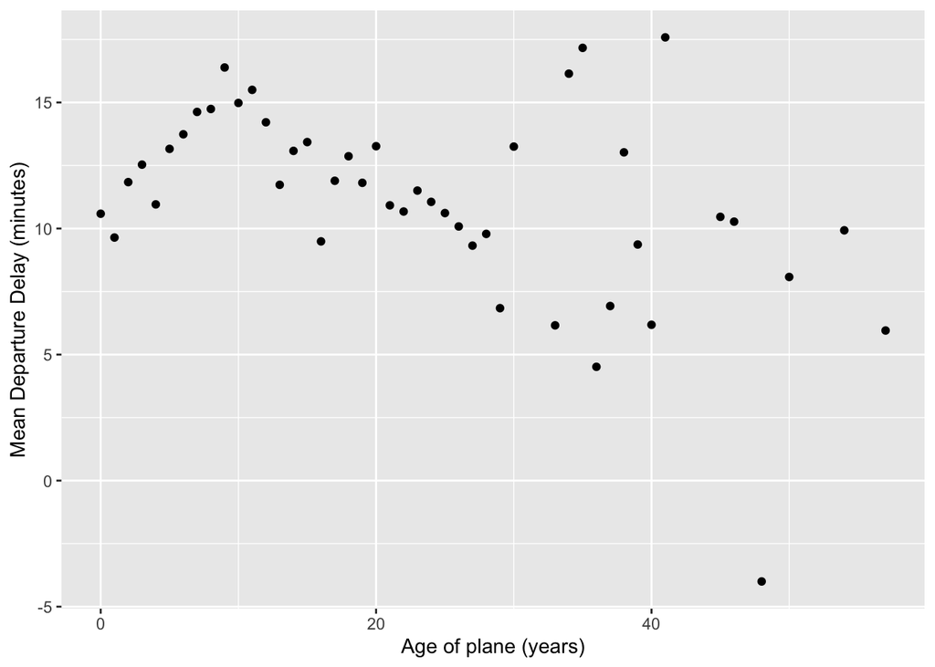

```r
library(nycflights13)

# Here is one solution (there are several ways we could address this question):

flights %>%
  left_join(select(planes, tailnum, plane_year = year)) %>%  # here we're subsetting the planes data to only include the relevant columns just to make it easier to view the intermediate output. We could also just join the entire dataset
  mutate(age = year - plane_year) %>%
  filter(!is.na(age)) %>%  # We saw earlier in lecture that not all planes in the flights data are included in the planes data, so we have to remove records with missing plane information to avoid getting error messages when we plot
  group_by(age) %>%
  summarize(delay = mean(dep_delay, na.rm = TRUE)) %>%  # we're choosing to look at departure delays, you could also look at arr_delay - another variable in flights
  ggplot(aes(age, delay)) +
  geom_point() +
  scale_x_continuous("Age of plane (years)") +
  scale_y_continuous("Mean Departure Delay (minutes)")
```